# Any voluntary/charitable activity

# 1 Description of DataSchema variable

The description of harmonised variables is the following:

- Short name: `volun`
- Variable label: `Any voluntary/charitable activity`
- Domain: `Social environment`
- Value type: `categorical`
- Categories:

| **Code** | **Category Label** |
| --- | --- |
| 0 | No |
| 1 | Yes |

- Category missings:

| **Code** | **Category Label** |
| --- | --- |
| 991 | CAPI/interviewer error |
| 992 | Impute |
| 993 | Disable to measure |
| 994 | Not attempt/not done |
| 995 | Does not answer |
| 996 | Not applicable |
| 997 | Refuse |
| 998 | Do not know |
| 999 | Missing |

# 2 Data process

## 2.1 England

### 2.1.1 Wave 1

#### 2.1.1.1 Study-specific variable description

The study-specific variables elected to be harmonised are:

- Name: `scorg4`
- Label: `Charitable associations`
- Categories:
  - `0 = No`
  - `1 = Yes`
- Missings:
  - `-9 = Not answered`
  - `-1 = Item not applicable`
- Name: `wpvw`
- Label: `How often -if at all- do you do any voluntary work?`
- Categories:
  - `1 = twice a month or more`
  - `2 = about once a month`
  - `3 = every few months`
  - `4 = about once or twice a year`
  - `5 = less than once a year`
  - `6 = never`
- Missings:
  - `-9 = Refusal`
  - `-8 = Don't Know`
  - `-1 = Not applicable`
- Description:

SCORG4

| Sample size | Missing values |
| --- | --- |
| 12099 | 1593 |

Category

|  | 0 | 1 |
| --- | --- | --- |
| Frequency | 8629.00 | 1877.00 |
| Percentage | 71.32 | 15.51 |

Type of missing

|  | -1 | -9 | NA |
| --- | --- | --- | --- |
| Frequency | 1108.00 | 485.00 | 0 |
| Percentage | 9.16 | 4.01 | 0 |

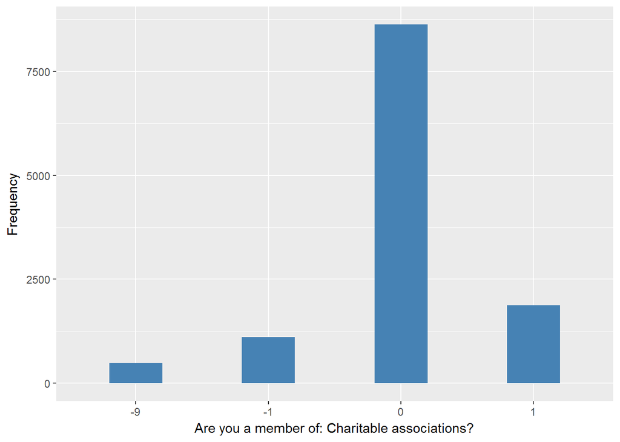

WPVW

| Sample size | Missing values |
| --- | --- |
| 12099 | 192 |

Category

|  | 1 | 2 | 3 | 4 | 5 | 6 |
| --- | --- | --- | --- | --- | --- | --- |
| Frequency | 1771.00 | 434.00 | 320.00 | 357.00 | 267.00 | 8758.00 |
| Percentage | 14.64 | 3.59 | 2.64 | 2.95 | 2.21 | 72.39 |

Type of missing

|  | -1 | -8 | -9 | NA |
| --- | --- | --- | --- | --- |
| Frequency | 175.00 | 12.0 | 5.00 | 0 |
| Percentage | 1.45 | 0.1 | 0.04 | 0 |

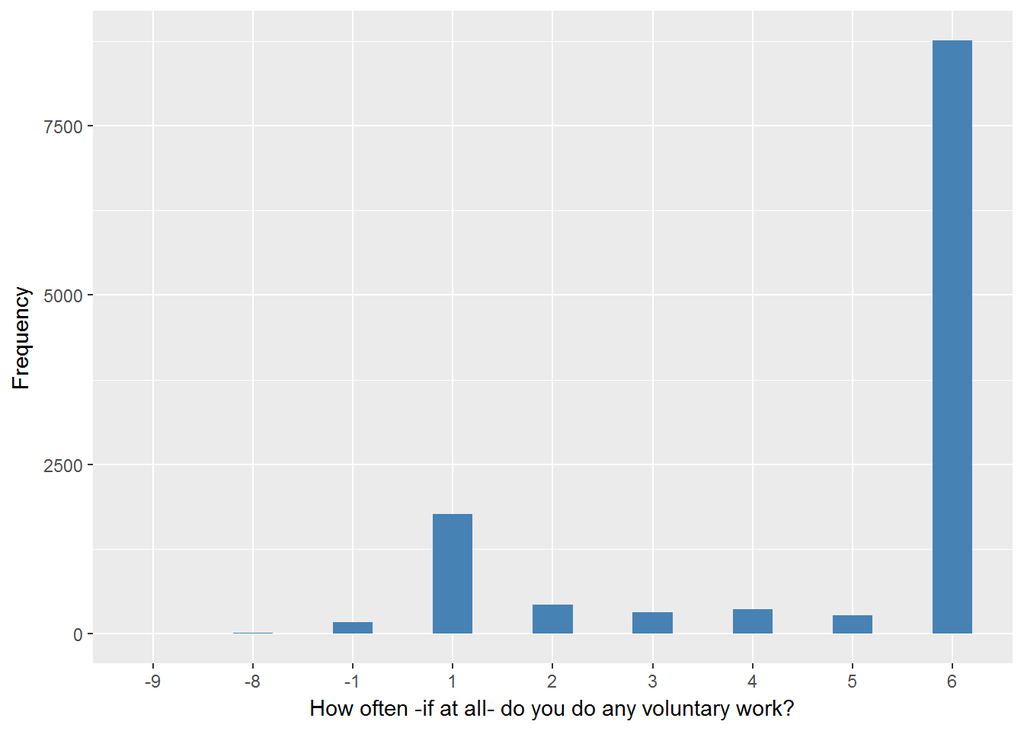

#### 2.1.1.2 Harmonisation algorithm

To compute the harmonize variable from the study-specific variable it has to be recoded as follows:

**R script:**

```r
ELSA_ds_w1 <- tibble(id = ELSA_w1_volun$id)

ELSA_w1_volun$scorg4 <- car::recode(as.vector(ELSA_w1_volun$scorg4), "NA='-999'")
ELSA_w1_volun$wpvw <- car::recode(as.vector(ELSA_w1_volun$wpvw), "NA='-999'")

ELSA_ds_w1$volun <- c(NA)
for (i in 1:dim(ELSA_w1_volun)[1]) {
    if (ELSA_w1_volun$scorg4[i] == 1 | ELSA_w1_volun$wpvw[i] %in% c(1, 2, 3)) {
        ELSA_ds_w1$volun[i] = 1
    } else if (ELSA_w1_volun$scorg4[i] == 0 & ELSA_w1_volun$wpvw[i] %in% c(4,
        5, 6)) {
        ELSA_ds_w1$volun[i] = 0
    } else if (ELSA_w1_volun$scorg4[i] == -1 | ELSA_w1_volun$wpvw[i] == -1) {
        ELSA_ds_w1$volun[i] = 996
    } else if (ELSA_w1_volun$scorg4[i] == -9) {
        ELSA_ds_w1$volun[i] = 995
    } else if (ELSA_w1_volun$wpvw[i] == -9) {
        ELSA_ds_w1$volun[i] = 997
    } else if (ELSA_w1_volun$wpvw[i] == -8) {
        ELSA_ds_w1$volun[i] = 998
    }
}

ELSA_ds_w1$volun <- car::recode(as.vector(ELSA_ds_w1$volun), "NA='999'")
ELSA_ds_w1$volun <- labelled(ELSA_ds_w1$volun, labels = c(No = 0, Yes = 1, Missing = 999,
    `Do not know` = 998, Refuse = 997, `Not applicable` = 996, `Don't answer` = 995,
    `Not attempt/not done/not yet recorded` = 994, `Disable to measure` = 993,
    Impute = 992, `CAPI/interviewer error` = 991))
```

#### 2.1.1.3 Statistical description of the new harmonised variable

| Sample size | Missing values |
| --- | --- |
| 12099 | 1455 |

Category

|  | 0 | 1 |
| --- | --- | --- |
| Frequency | 7352.00 | 3292.00 |
| Percentage | 60.77 | 27.21 |

Type of missing

|  | 991 | 992 | 993 | 994 | 995 | 996 | 997 | 998 | 999 | NA |
| --- | --- | --- | --- | --- | --- | --- | --- | --- | --- | --- |
| Frequency | 0 | 0 | 0 | 0 | 451.00 | 1002.00 | 0 | 2.00 | 0 | 0 |
| Percentage | 0 | 0 | 0 | 0 | 3.73 | 8.28 | 0 | 0.02 | 0 | 0 |

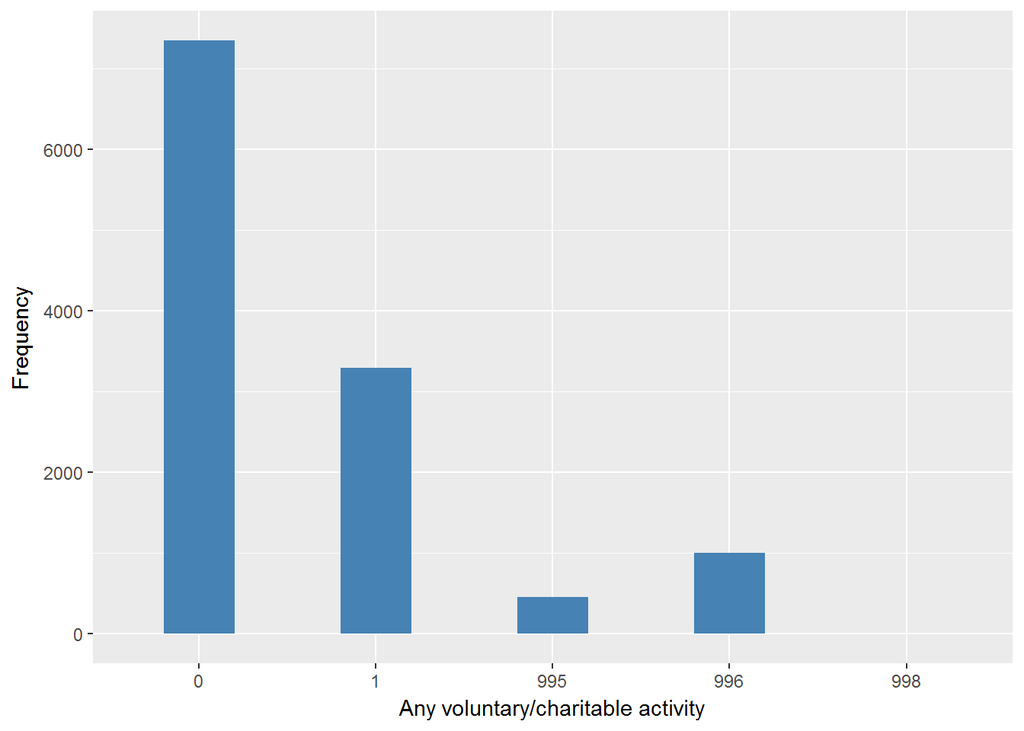

#### 2.1.1.4 Validation

### 2.1.2 Wave 2

#### 2.1.2.1 Study-specific variable description

The study-specific variable elected to be harmonised is:

- Name: `scorg04`
- Label: `Organisational membership: member of a charitable association`
- Categories:
  - `0 = No`
  - `1 = Yes`
- Missings:
  - `-9 = Not answered`
  - `-1 = Item not applicable`
- Name: `wpvw`
- Label: `How often does voluntary work?`
- Categories:
  - `1 = twice a month or more`
  - `2 = about once a month`
  - `3 = every few months`
  - `4 = about once or twice a year`
  - `5 = less than once a year`
  - `6 = never`
- Missings:
  - `-9 = Refusal`
  - `-8 = Don't Know`
  - `-1 = Not applicable`
- Description:

SCORG04

| Sample size | Missing values |
| --- | --- |
| 9432 | 1666 |

Category

|  | 0 | 1 |
| --- | --- | --- |
| Frequency | 6320.00 | 1446.00 |
| Percentage | 67.01 | 15.33 |

Type of missing

|  | -1 | -9 | NA |
| --- | --- | --- | --- |
| Frequency | 1072.00 | 594.0 | 0 |
| Percentage | 11.37 | 6.3 | 0 |

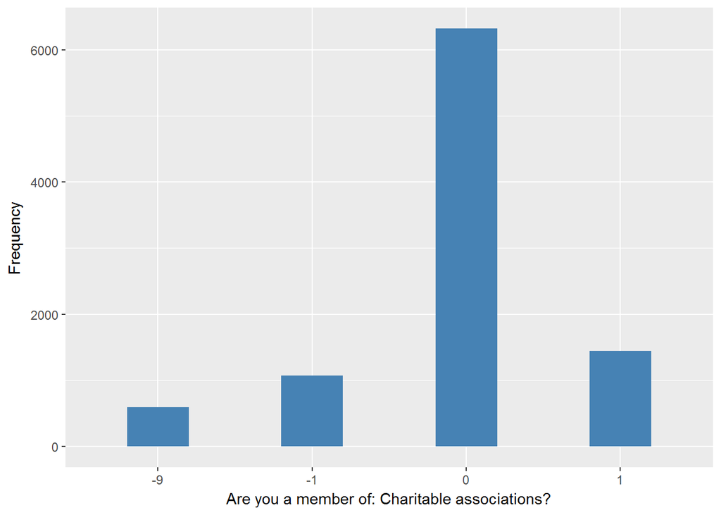

WPVW

| Sample size | Missing values |
| --- | --- |
| 9432 | 135 |

Category

|  | 1 | 2 | 3 | 4 | 5 | 6 |
| --- | --- | --- | --- | --- | --- | --- |
| Frequency | 1495.00 | 351.00 | 251.00 | 281.00 | 129.00 | 6790.00 |
| Percentage | 15.85 | 3.72 | 2.66 | 2.98 | 1.37 | 71.99 |

Type of missing

|  | -1 | -8 | -9 | NA |
| --- | --- | --- | --- | --- |
| Frequency | 132.0 | 2.00 | 1.00 | 0 |
| Percentage | 1.4 | 0.02 | 0.01 | 0 |

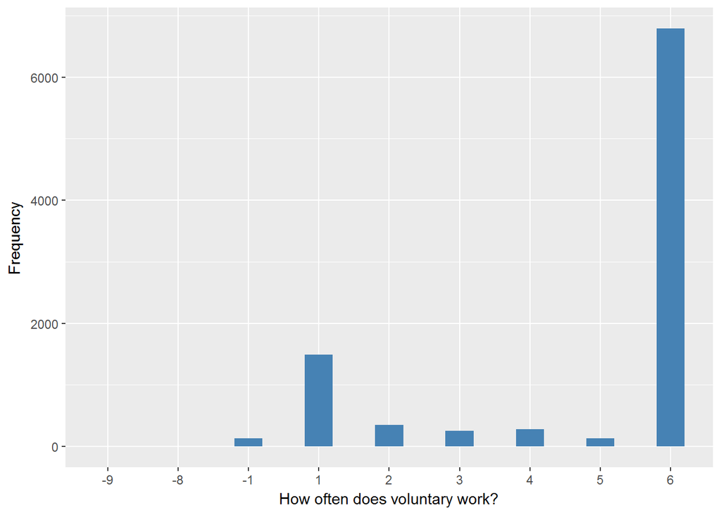

#### 2.1.2.2 Harmonisation algorithm

To compute the harmonize variable from the study-specific variable it has to be recoded as follows:

**R script:**

```r
ELSA_ds_w2 <- tibble(id = ELSA_w2_volun$id)

ELSA_w2_volun$scorg04 <- car::recode(as.vector(ELSA_w2_volun$scorg04), "NA='-999'")
ELSA_w2_volun$wpvw <- car::recode(as.vector(ELSA_w2_volun$wpvw), "NA='-999'")

ELSA_ds_w2$volun <- c(NA)
for (i in 1:dim(ELSA_w2_volun)[1]) {
    if (ELSA_w2_volun$scorg04[i] == 1 | ELSA_w2_volun$wpvw[i] %in% c(1, 2, 3)) {
        ELSA_ds_w2$volun[i] = 1
    } else if (ELSA_w2_volun$scorg04[i] == 0 & ELSA_w2_volun$wpvw[i] %in% c(4,
        5, 6)) {
        ELSA_ds_w2$volun[i] = 0
    } else if (ELSA_w2_volun$scorg04[i] == -1 | ELSA_w2_volun$wpvw[i] == -1) {
        ELSA_ds_w2$volun[i] = 996
    } else if (ELSA_w2_volun$scorg04[i] == -9) {
        ELSA_ds_w2$volun[i] = 995
    } else if (ELSA_w2_volun$wpvw[i] == -9) {
        ELSA_ds_w2$volun[i] = 997
    } else if (ELSA_w2_volun$wpvw[i] == -8) {
        ELSA_ds_w2$volun[i] = 998
    }
}

ELSA_ds_w2$volun <- car::recode(as.vector(ELSA_ds_w2$volun), "NA='999'")
ELSA_ds_w2$volun <- labelled(ELSA_ds_w2$volun, labels = c(No = 0, Yes = 1, Missing = 999,
    `Do not know` = 998, Refuse = 997, `Not applicable` = 996, `Don't answer` = 995,
    `Not attempt/not done/not yet recorded` = 994, `Disable to measure` = 993,
    Impute = 992, `CAPI/interviewer error` = 991))
```

#### 2.1.2.3 Statistical description of the new harmonised variable

| Sample size | Missing values |
| --- | --- |
| 9432 | 1507 |

Category

|  | 0 | 1 |
| --- | --- | --- |
| Frequency | 5214.00 | 2711.00 |
| Percentage | 55.28 | 28.74 |

Type of missing

|  | 991 | 992 | 993 | 994 | 995 | 996 | 997 | 998 | 999 | NA |
| --- | --- | --- | --- | --- | --- | --- | --- | --- | --- | --- |
| Frequency | 0 | 0 | 0 | 0 | 549.00 | 957.00 | 0 | 1.00 | 0 | 0 |
| Percentage | 0 | 0 | 0 | 0 | 5.82 | 10.15 | 0 | 0.01 | 0 | 0 |

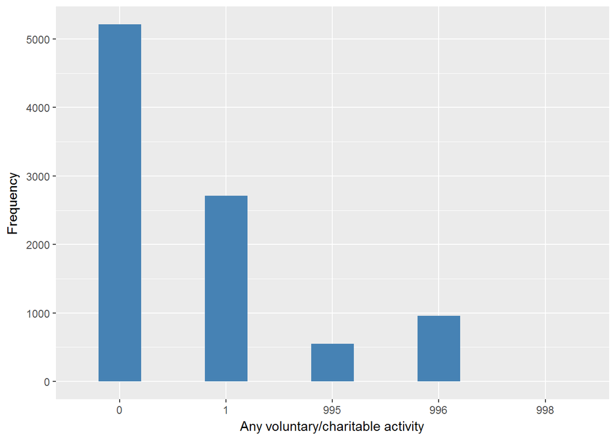

#### 2.1.2.4 Validation

### 2.1.3 Wave 3

#### 2.1.3.1 Study-specific variable description

The study-specific variable elected to be harmonised is:

- Name: `scorg04`
- Label: `Respondent is a member of charitable associations`
- Categories:
  - `0 = No`
  - `1 = Yes`
- Missings:
  - `-9 = Not answered`
  - `-8 = Don't know`
  - `-1 = Item not applicable`
- Name: `wpvw`
- Label: `How often does voluntary work?`
- Categories:
  - `1 = twice a month or more`
  - `2 = about once a month`
  - `3 = every few months`
  - `4 = about once or twice a year`
  - `5 = less than once a year`
  - `6 = never`
- Missings:
  - `-9 = Refusal`
  - `-8 = Don't Know`
  - `-2 = Schedule not applicable`
  - `-1 = Not applicable`
- Description:

SCORG04

| Sample size | Missing values |
| --- | --- |
| 9771 | 2006 |

Category

|  | 0 | 1 |
| --- | --- | --- |
| Frequency | 6347.00 | 1418.00 |
| Percentage | 64.96 | 14.51 |

Type of missing

|  | -1 | -8 | -9 | NA |
| --- | --- | --- | --- | --- |
| Frequency | 1527.00 | 0 | 479.0 | 0 |
| Percentage | 15.63 | 0 | 4.9 | 0 |

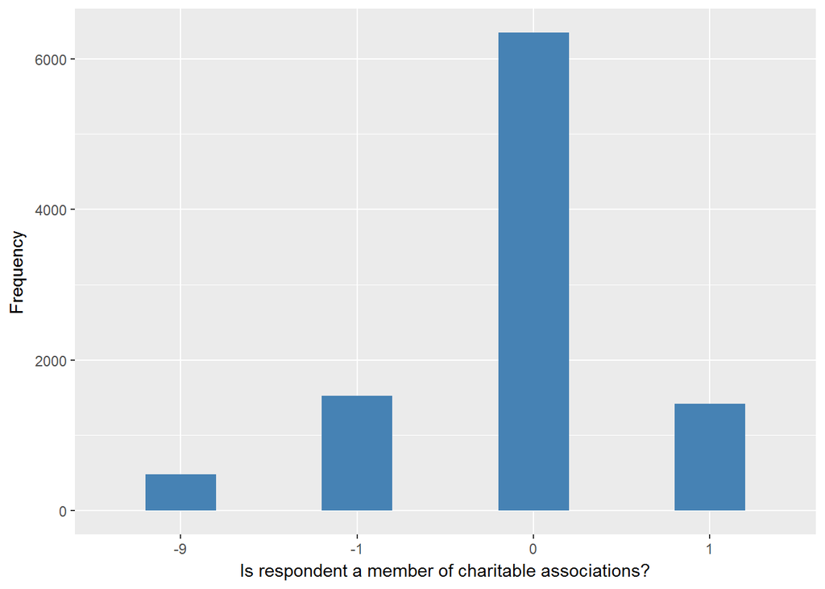

WPVW

| Sample size | Missing values |
| --- | --- |
| 9771 | 238 |

Category

|  | 1 | 2 | 3 | 4 | 5 | 6 |
| --- | --- | --- | --- | --- | --- | --- |
| Frequency | 1571.00 | 402.00 | 268.00 | 280.00 | 130.00 | 6882.00 |
| Percentage | 16.08 | 4.11 | 2.74 | 2.87 | 1.33 | 70.43 |

Type of missing

|  | -1 | -2 | -8 | -9 | NA |
| --- | --- | --- | --- | --- | --- |
| Frequency | 232.00 | 0 | 5.00 | 1.00 | 0 |
| Percentage | 2.37 | 0 | 0.05 | 0.01 | 0 |

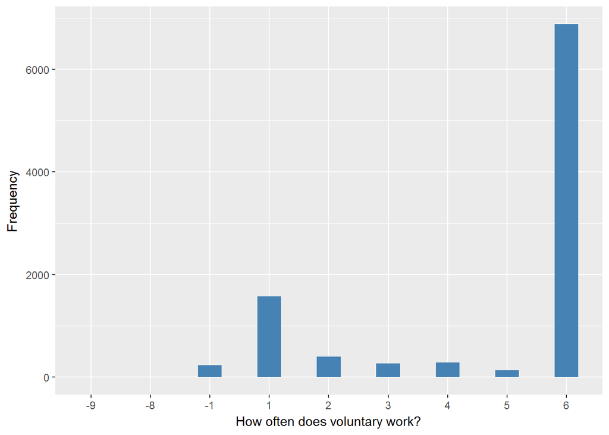

#### 2.1.3.2 Harmonisation algorithm

To compute the harmonize variable from the study-specific variable it has to be recoded as follows:

**R script:**

```r
ELSA_ds_w3 <- tibble(id = ELSA_w3_volun$id)

ELSA_w3_volun$scorg04 <- car::recode(as.vector(ELSA_w3_volun$scorg04), "NA='-999'")
ELSA_w3_volun$wpvw <- car::recode(as.vector(ELSA_w3_volun$wpvw), "NA='-999'")

ELSA_ds_w3$volun <- c(NA)
for (i in 1:dim(ELSA_w3_volun)[1]) {
    if (ELSA_w3_volun$scorg04[i] == 1 | ELSA_w3_volun$wpvw[i] %in% c(1, 2, 3)) {
        ELSA_ds_w3$volun[i] = 1
    } else if (ELSA_w3_volun$scorg04[i] == 0 & ELSA_w3_volun$wpvw[i] %in% c(4,
        5, 6)) {
        ELSA_ds_w3$volun[i] = 0
    } else if (ELSA_w3_volun$scorg04[i] == -1 | ELSA_w3_volun$wpvw[i] %in% c(-1,
        -2)) {
        ELSA_ds_w3$volun[i] = 996
    } else if (ELSA_w3_volun$scorg04[i] == -9) {
        ELSA_ds_w3$volun[i] = 995
    } else if (ELSA_w3_volun$wpvw[i] == -9) {
        ELSA_ds_w3$volun[i] = 997
    } else if (ELSA_w3_volun$scorg04[i] == -8 | ELSA_w3_volun$wpvw[i] == -8) {
        ELSA_ds_w3$volun[i] = 998
    }
}

ELSA_ds_w3$volun <- car::recode(as.vector(ELSA_ds_w3$volun), "NA='999'")
ELSA_ds_w3$volun <- labelled(ELSA_ds_w3$volun, labels = c(No = 0, Yes = 1, Missing = 999,
    `Do not know` = 998, Refuse = 997, `Not applicable` = 996, `Don't answer` = 995,
    `Not attempt/not done/not yet recorded` = 994, `Disable to measure` = 993,
    Impute = 992, `CAPI/interviewer error` = 991))
```

#### 2.1.3.3 Statistical description of the new harmonised variable

| Sample size | Missing values |
| --- | --- |
| 9771 | 1753 |

Category

|  | 0 | 1 |
| --- | --- | --- |
| Frequency | 5229.00 | 2789.00 |
| Percentage | 53.52 | 28.54 |

Type of missing

|  | 991 | 992 | 993 | 994 | 995 | 996 | 997 | 998 | 999 | NA |
| --- | --- | --- | --- | --- | --- | --- | --- | --- | --- | --- |
| Frequency | 0 | 0 | 0 | 0 | 424.00 | 1328.00 | 0 | 1.00 | 0 | 0 |
| Percentage | 0 | 0 | 0 | 0 | 4.34 | 13.59 | 0 | 0.01 | 0 | 0 |

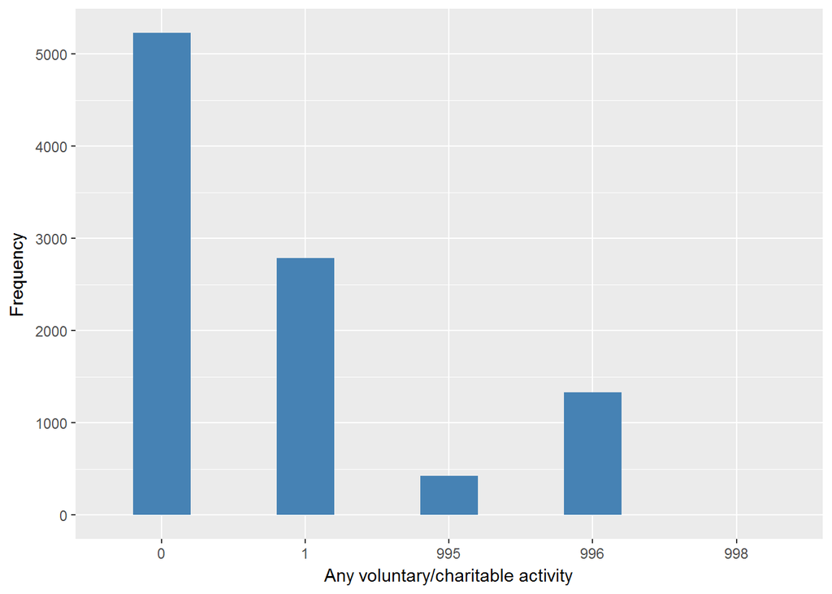

#### 2.1.3.4 Validation

### 2.1.4 Wave 4

#### 2.1.4.1 Study-specific variable description

The study-specific variable elected to be harmonised is:

- Name: `scorg04`
- Label: `Respondent is a member of charitable associations`
- Categories:
  - `0 = No`
  - `1 = Yes`
- Missings:
  - `-9 = Not answered`
  - `-8 = Don't know`
  - `-1 = Item not applicable`
- Name: `wpvw`
- Label: `How often does voluntary work?`
- Categories:
  - `1 = twice a month or more`
  - `2 = about once a month`
  - `3 = every few months`
  - `4 = about once or twice a year`
  - `5 = less than once a year`
  - `6 = never`
- Missings:
  - `-9 = Refusal`
  - `-8 = Don't Know`
  - `-2 = Schedule not applicable`
  - `-1 = Not applicable`
- Description:

SCORG04

| Sample size | Missing values |
| --- | --- |
| 11050 | 2170 |

Category

|  | 0 | 1 |
| --- | --- | --- |
| Frequency | 7261.00 | 1619.00 |
| Percentage | 65.71 | 14.65 |

Type of missing

|  | -1 | -8 | -9 | NA |
| --- | --- | --- | --- | --- |
| Frequency | 1708.00 | 0 | 462.00 | 0 |
| Percentage | 15.46 | 0 | 4.18 | 0 |

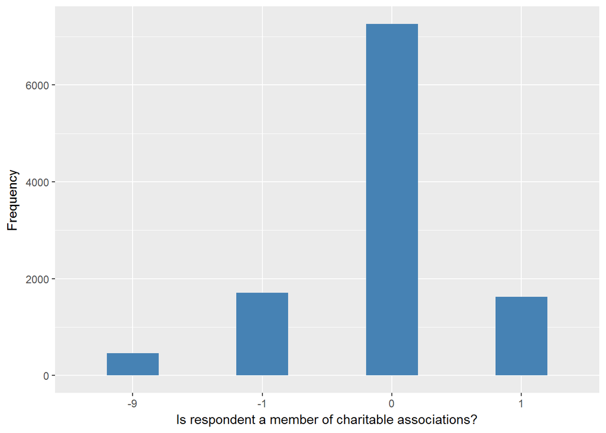

WPVW

| Sample size | Missing values |
| --- | --- |
| 11050 | 456 |

Category

|  | 1 | 2 | 3 | 4 | 5 | 6 |
| --- | --- | --- | --- | --- | --- | --- |
| Frequency | 1819.00 | 477.00 | 287.0 | 299.00 | 192.00 | 7520.00 |
| Percentage | 16.46 | 4.32 | 2.6 | 2.71 | 1.74 | 68.05 |

Type of missing

|  | -1 | -2 | -8 | -9 | NA |
| --- | --- | --- | --- | --- | --- |
| Frequency | 446.00 | 0 | 3.00 | 7.00 | 0 |
| Percentage | 4.04 | 0 | 0.03 | 0.06 | 0 |

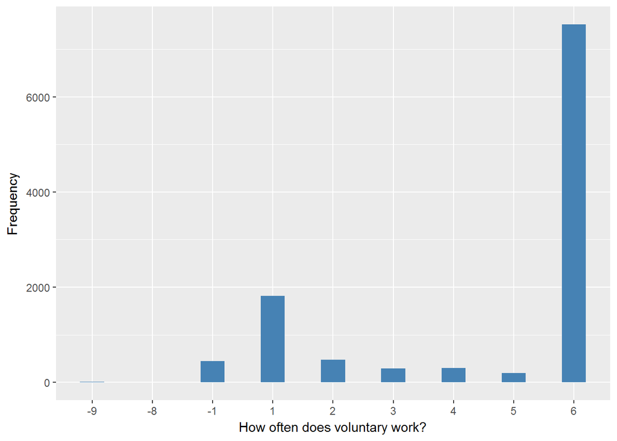

#### 2.1.4.2 Harmonisation algorithm

To compute the harmonize variable from the study-specific variable it has to be recoded as follows:

**R script:**

```r
ELSA_ds_w4 <- tibble(id = ELSA_w4_volun$id)

ELSA_w4_volun$scorg04 <- car::recode(as.vector(ELSA_w4_volun$scorg04), "NA='-999'")
ELSA_w4_volun$wpvw <- car::recode(as.vector(ELSA_w4_volun$wpvw), "NA='-999'")

ELSA_ds_w4$volun <- c(NA)
for (i in 1:dim(ELSA_w4_volun)[1]) {
    if (ELSA_w4_volun$scorg04[i] == 1 | ELSA_w4_volun$wpvw[i] %in% c(1, 2, 3)) {
        ELSA_ds_w4$volun[i] = 1
    } else if (ELSA_w4_volun$scorg04[i] == 0 & ELSA_w4_volun$wpvw[i] %in% c(4,
        5, 6)) {
        ELSA_ds_w4$volun[i] = 0
    } else if (ELSA_w4_volun$scorg04[i] == -1 | ELSA_w4_volun$wpvw[i] %in% c(-1,
        -2)) {
        ELSA_ds_w4$volun[i] = 996
    } else if (ELSA_w4_volun$scorg04[i] == -9) {
        ELSA_ds_w4$volun[i] = 995
    } else if (ELSA_w4_volun$wpvw[i] == -9) {
        ELSA_ds_w4$volun[i] = 997
    } else if (ELSA_w4_volun$scorg04[i] == -8 | ELSA_w4_volun$wpvw[i] == -8) {
        ELSA_ds_w4$volun[i] = 998
    }
}

ELSA_ds_w4$volun <- car::recode(as.vector(ELSA_ds_w4$volun), "NA='999'")
ELSA_ds_w4$volun <- labelled(ELSA_ds_w4$volun, labels = c(No = 0, Yes = 1, Missing = 999,
    `Do not know` = 998, Refuse = 997, `Not applicable` = 996, `Don't answer` = 995,
    `Not attempt/not done/not yet recorded` = 994, `Disable to measure` = 993,
    Impute = 992, `CAPI/interviewer error` = 991))
```

#### 2.1.4.3 Statistical description of the new harmonised variable

| Sample size | Missing values |
| --- | --- |
| 11050 | 1920 |

Category

|  | 0 | 1 |
| --- | --- | --- |
| Frequency | 5925.00 | 3205 |
| Percentage | 53.62 | 29 |

Type of missing

|  | 991 | 992 | 993 | 994 | 995 | 996 | 997 | 998 | 999 | NA |
| --- | --- | --- | --- | --- | --- | --- | --- | --- | --- | --- |
| Frequency | 0 | 0 | 0 | 0 | 414.00 | 1505.00 | 0 | 1.00 | 0 | 0 |
| Percentage | 0 | 0 | 0 | 0 | 3.75 | 13.62 | 0 | 0.01 | 0 | 0 |

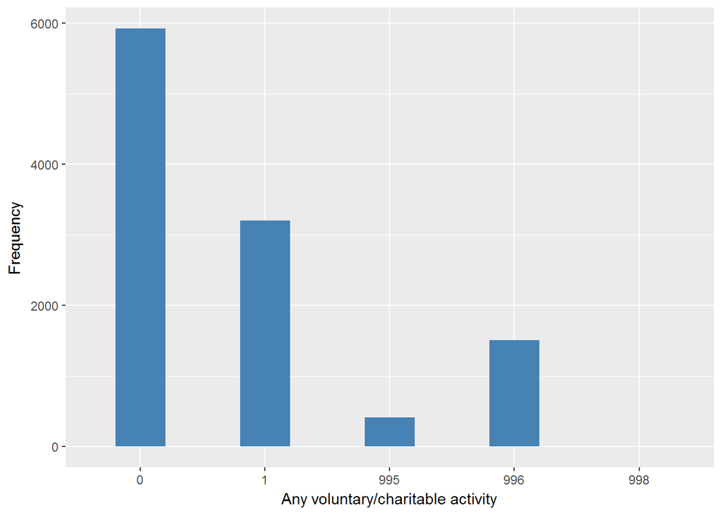

#### 2.1.4.4 Validation

### 2.1.5 Wave 5

#### 2.1.5.1 Study-specific variable description

The study-specific variable elected to be harmonised is:

- Name: `scorg04`
- Label: `Respondent is a member of charitable associations`
- Categories:
  - `0 = No`
  - `1 = Yes`
- Missings:
  - `-9 = Not answered`
  - `-8 = Don't know`
  - `-2 = Schedule not applicable`
  - `-1 = Item not applicable`
- Name: `wpvw`
- Label: `How often does voluntary work?`
- Categories:
  - `1 = twice a month or more`
  - `2 = about once a month`
  - `3 = every few months`
  - `4 = about once or twice a year`
  - `5 = less than once a year`
  - `6 = never`
- Missings:
  - `-9 = Refusal`
  - `-8 = Don't Know`
  - `-2 = Schedule not applicable`
  - `-1 = Not applicable`
- Description:

SCORG04

| Sample size | Missing values |
| --- | --- |
| 10274 | 1729 |

Category

|  | 0 | 1 |
| --- | --- | --- |
| Frequency | 6925.0 | 1620.00 |
| Percentage | 67.4 | 15.77 |

Type of missing

|  | -1 | -2 | -8 | -9 | NA |
| --- | --- | --- | --- | --- | --- |
| Frequency | 0 | 1244.00 | 0 | 485.00 | 0 |
| Percentage | 0 | 12.11 | 0 | 4.72 | 0 |

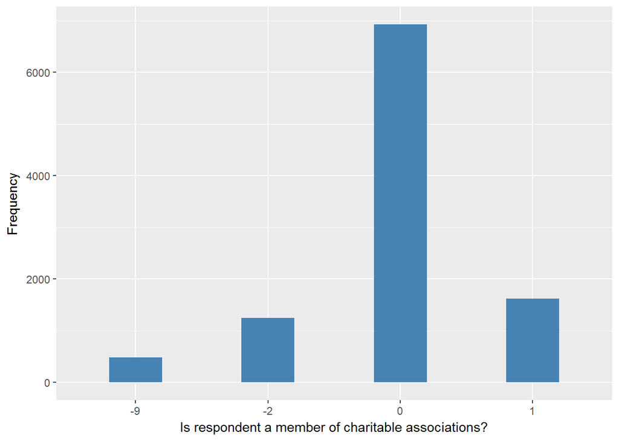

WPVW

| Sample size | Missing values |
| --- | --- |
| 10274 | 543 |

Category

|  | 1 | 2 | 3 | 4 | 5 | 6 |
| --- | --- | --- | --- | --- | --- | --- |
| Frequency | 1745.00 | 419.00 | 301.00 | 299.00 | 186.00 | 6781 |
| Percentage | 16.98 | 4.08 | 2.93 | 2.91 | 1.81 | 66 |

Type of missing

|  | -1 | -2 | -8 | -9 | NA |
| --- | --- | --- | --- | --- | --- |
| Frequency | 537.00 | 0 | 3.00 | 3.00 | 0 |
| Percentage | 5.23 | 0 | 0.03 | 0.03 | 0 |

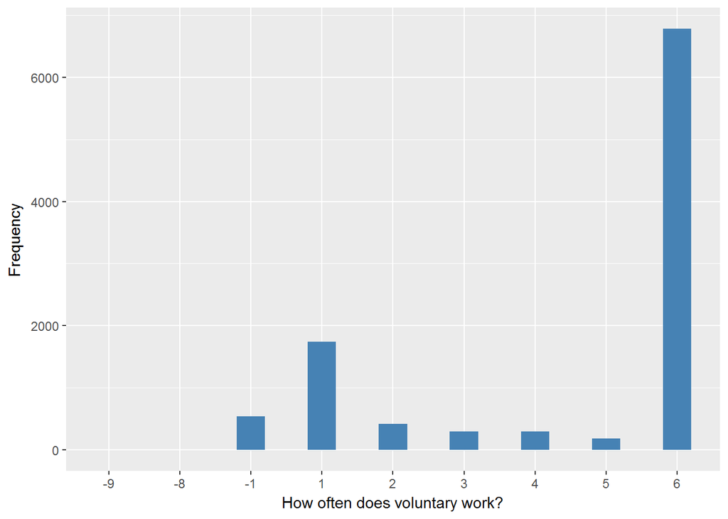

#### 2.1.5.2 Harmonisation algorithm

To compute the harmonize variable from the study-specific variable it has to be recoded as follows:

**R script:**

```r
ELSA_ds_w5 <- tibble(id = ELSA_w5_volun$id)

ELSA_w5_volun$scorg04 <- car::recode(as.vector(ELSA_w5_volun$scorg04), "NA='-999'")
ELSA_w5_volun$wpvw <- car::recode(as.vector(ELSA_w5_volun$wpvw), "NA='-999'")

ELSA_ds_w5$volun <- c(NA)
for (i in 1:dim(ELSA_w5_volun)[1]) {
    if (ELSA_w5_volun$scorg04[i] == 1 | ELSA_w5_volun$wpvw[i] %in% c(1, 2, 3)) {
        ELSA_ds_w5$volun[i] = 1
    } else if (ELSA_w5_volun$scorg04[i] == 0 & ELSA_w5_volun$wpvw[i] %in% c(4,
        5, 6)) {
        ELSA_ds_w5$volun[i] = 0
    } else if (ELSA_w5_volun$scorg04[i] %in% c(-1, -2) | ELSA_w5_volun$wpvw[i] %in%
        c(-1, -2)) {
        ELSA_ds_w5$volun[i] = 996
    } else if (ELSA_w5_volun$scorg04[i] == -9) {
        ELSA_ds_w5$volun[i] = 995
    } else if (ELSA_w5_volun$wpvw[i] == -9) {
        ELSA_ds_w5$volun[i] = 997
    } else if (ELSA_w5_volun$scorg04[i] == -8 | ELSA_w5_volun$wpvw[i] == -8) {
        ELSA_ds_w5$volun[i] = 998
    }
}

ELSA_ds_w5$volun <- car::recode(as.vector(ELSA_ds_w5$volun), "NA='999'")
ELSA_ds_w5$volun <- labelled(ELSA_ds_w5$volun, labels = c(No = 0, Yes = 1, Missing = 999,
    `Do not know` = 998, Refuse = 997, `Not applicable` = 996, `Don't answer` = 995,
    `Not attempt/not done/not yet recorded` = 994, `Disable to measure` = 993,
    Impute = 992, `CAPI/interviewer error` = 991))
```

#### 2.1.5.3 Statistical description of the new harmonised variable

| Sample size | Missing values |
| --- | --- |
| 10274 | 1592 |

Category

|  | 0 | 1 |
| --- | --- | --- |
| Frequency | 5616.00 | 3066.00 |
| Percentage | 54.66 | 29.84 |

Type of missing

|  | 991 | 992 | 993 | 994 | 995 | 996 | 997 | 998 | 999 | NA |
| --- | --- | --- | --- | --- | --- | --- | --- | --- | --- | --- |
| Frequency | 0 | 0 | 0 | 0 | 435.00 | 1157.00 | 0 | 0 | 0 | 0 |
| Percentage | 0 | 0 | 0 | 0 | 4.23 | 11.26 | 0 | 0 | 0 | 0 |

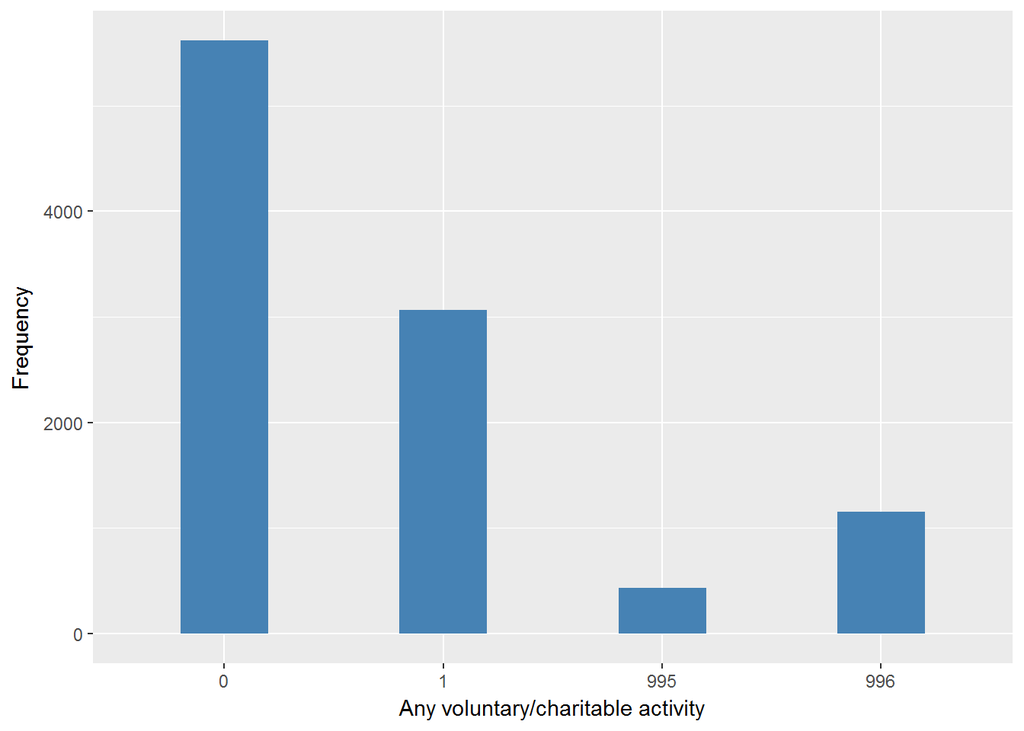

#### 2.1.5.4 Validation

### 2.1.6 Wave 6

#### 2.1.6.1 Study-specific variable description

The study-specific variable elected to be harmonised is:

- Name: `scorg04`
- Label: `Respondent is a member of charitable associations`
- Categories:
  - `0 = No`
  - `1 = Yes`
- Missings:
  - `-9 = Not answered`
  - `-8 = Don't know`
  - `-2 = Schedule not applicable`
  - `-1 = Item not applicable`
- Name: `WpVW`
- Label: `How often does voluntary work?`
- Categories:
  - `1 = twice a month or more`
  - `2 = about once a month`
  - `3 = every few months`
  - `4 = about once or twice a year`
  - `5 = less than once a year`
  - `6 = never`
- Missings:
  - `-9 = Refusal`
  - `-8 = Don't Know`
  - `-2 = Schedule not applicable`
  - `-1 = Not applicable`
- Description:

SCORG04

| Sample size | Missing values |
| --- | --- |
| 10601 | 2026 |

Category

|  | 0 | 1 |
| --- | --- | --- |
| Frequency | 6908.00 | 1667.00 |
| Percentage | 65.16 | 15.72 |

Type of missing

|  | -1 | -2 | -8 | -9 | NA |
| --- | --- | --- | --- | --- | --- |
| Frequency | 0 | 1604.00 | 0 | 422.00 | 0 |
| Percentage | 0 | 15.13 | 0 | 3.98 | 0 |

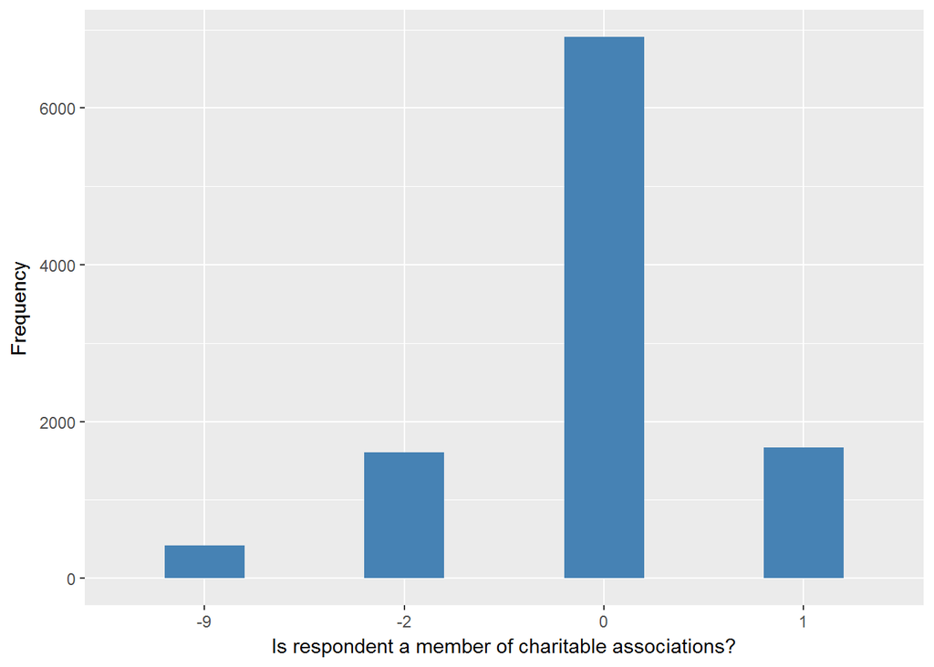

WPVW

| Sample size | Missing values |
| --- | --- |
| 10601 | 619 |

Category

|  | 1 | 2 | 3 | 4 | 5 | 6 |
| --- | --- | --- | --- | --- | --- | --- |
| Frequency | 1842.00 | 400.00 | 280.00 | 267.00 | 166.00 | 7027.00 |
| Percentage | 17.38 | 3.77 | 2.64 | 2.52 | 1.57 | 66.29 |

Type of missing

|  | -1 | -2 | -8 | -9 | NA |
| --- | --- | --- | --- | --- | --- |
| Frequency | 614.00 | 0 | 2.00 | 3.00 | 0 |
| Percentage | 5.79 | 0 | 0.02 | 0.03 | 0 |

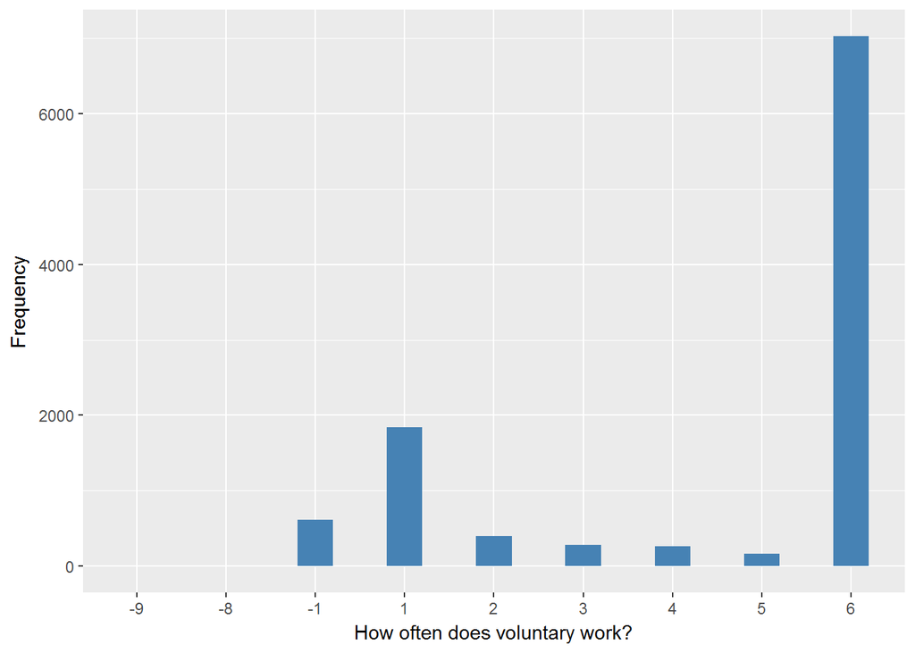

#### 2.1.6.2 Harmonisation algorithm

To compute the harmonize variable from the study-specific variable it has to be recoded as follows:

**R script:**

```r
ELSA_ds_w6 <- tibble(id = ELSA_w6_volun$id)

ELSA_w6_volun$scorg04 <- car::recode(as.vector(ELSA_w6_volun$scorg04), "NA='-999'")
ELSA_w6_volun$WpVW <- car::recode(as.vector(ELSA_w6_volun$WpVW), "NA='-999'")

ELSA_ds_w6$volun <- c(NA)
for (i in 1:dim(ELSA_w6_volun)[1]) {
    if (ELSA_w6_volun$scorg04[i] == 1 | ELSA_w6_volun$WpVW[i] %in% c(1, 2, 3)) {
        ELSA_ds_w6$volun[i] = 1
    } else if (ELSA_w6_volun$scorg04[i] == 0 & ELSA_w6_volun$WpVW[i] %in% c(4,
        5, 6)) {
        ELSA_ds_w6$volun[i] = 0
    } else if (ELSA_w6_volun$scorg04[i] %in% c(-1, -2) | ELSA_w6_volun$WpVW[i] %in%
        c(-1, -2)) {
        ELSA_ds_w6$volun[i] = 996
    } else if (ELSA_w6_volun$scorg04[i] == -9) {
        ELSA_ds_w6$volun[i] = 995
    } else if (ELSA_w6_volun$WpVW[i] == -9) {
        ELSA_ds_w6$volun[i] = 997
    } else if (ELSA_w6_volun$scorg04[i] == -8 | ELSA_w6_volun$WpVW[i] == -8) {
        ELSA_ds_w6$volun[i] = 998
    }
}

ELSA_ds_w6$volun <- car::recode(as.vector(ELSA_ds_w6$volun), "NA='999'")
ELSA_ds_w6$volun <- labelled(ELSA_ds_w6$volun, labels = c(No = 0, Yes = 1, Missing = 999,
    `Do not know` = 998, Refuse = 997, `Not applicable` = 996, `Don't answer` = 995,
    `Not attempt/not done/not yet recorded` = 994, `Disable to measure` = 993,
    Impute = 992, `CAPI/interviewer error` = 991))
```

#### 2.1.6.3 Statistical description of the new harmonised variable

| Sample size | Missing values |
| --- | --- |
| 10601 | 1832 |

Category

|  | 0 | 1 |
| --- | --- | --- |
| Frequency | 5616.00 | 3153.00 |
| Percentage | 52.98 | 29.74 |

Type of missing

|  | 991 | 992 | 993 | 994 | 995 | 996 | 997 | 998 | 999 | NA |
| --- | --- | --- | --- | --- | --- | --- | --- | --- | --- | --- |
| Frequency | 0 | 0 | 0 | 0 | 392.0 | 1440.00 | 0 | 0 | 0 | 0 |
| Percentage | 0 | 0 | 0 | 0 | 3.7 | 13.58 | 0 | 0 | 0 | 0 |

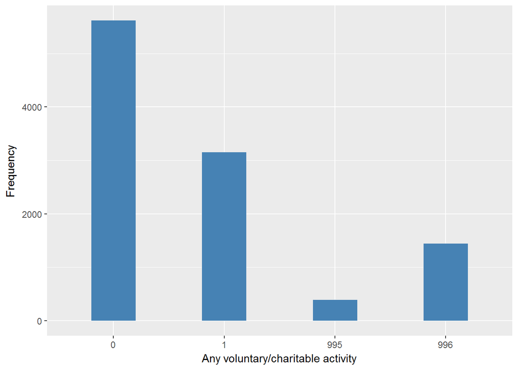

#### 2.1.6.4 Validation

### 2.1.7 Wave 7

#### 2.1.7.1 Study-specific variable description

The study-specific variable elected to be harmonised is:

- Name: `scorg04`
- Label: `Respondent is a member of charitable associations`
- Categories:
  - `0 = No`
  - `1 = Yes`
- Missings:
  - `-9 = Not answered`
  - `-8 = Don't know`
  - `-2 = Schedule not applicable`
  - `-1 = Item not applicable`
- Name: `WpVW`
- Label: `How often does voluntary work?`
- Categories:
  - `1 = twice a month or more`
  - `2 = about once a month`
  - `3 = every few months`
  - `4 = about once or twice a year`
  - `5 = less than once a year`
  - `6 = never`
- Missings:
  - `-9 = Refusal`
  - `-8 = Don't Know`
  - `-2 = Schedule not applicable`
  - `-1 = Not applicable`
- Description:

| Sample size | Missing values |
| --- | --- |
| 9666 | 1863 |

Category

|  | 0 | 1 |
| --- | --- | --- |
| Frequency | 6344.00 | 1459.00 |
| Percentage | 65.63 | 15.09 |

Type of missing

|  | -1 | -2 | -8 | -9 | NA |
| --- | --- | --- | --- | --- | --- |
| Frequency | 0 | 1469.0 | 0 | 394.00 | 0 |
| Percentage | 0 | 15.2 | 0 | 4.08 | 0 |

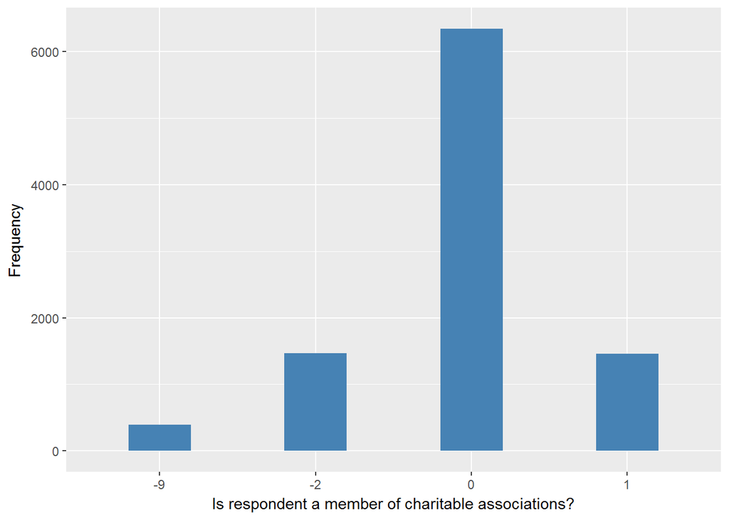

| Sample size | Missing values |
| --- | --- |
| 9666 | 599 |

Category

|  | 1 | 2 | 3 | 4 | 5 | 6 |
| --- | --- | --- | --- | --- | --- | --- |
| Frequency | 1682.0 | 344.00 | 254.00 | 224.00 | 129.00 | 6434.00 |
| Percentage | 17.4 | 3.56 | 2.63 | 2.32 | 1.33 | 66.56 |

Type of missing

|  | -1 | -2 | -8 | -9 | NA |
| --- | --- | --- | --- | --- | --- |
| Frequency | 597.00 | 0 | 2.00 | 0 | 0 |
| Percentage | 6.18 | 0 | 0.02 | 0 | 0 |

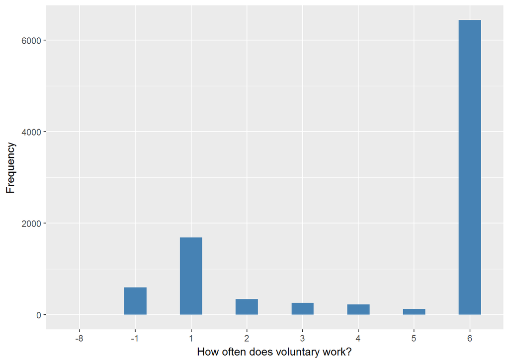

#### 2.1.7.2 Harmonisation algorithm

To compute the harmonize variable from the study-specific variable it has to be recoded as follows:

**R script:**

```r
ELSA_ds_w7 <- tibble(id = ELSA_w7_volun$id)

ELSA_w7_volun$scorg04 <- car::recode(as.vector(ELSA_w7_volun$scorg04), "NA='-999'")
ELSA_w7_volun$WpVW <- car::recode(as.vector(ELSA_w7_volun$WpVW), "NA='-999'")

ELSA_ds_w7$volun <- c(NA)
for (i in 1:dim(ELSA_w7_volun)[1]) {
    if (ELSA_w7_volun$scorg04[i] == 1 | ELSA_w7_volun$WpVW[i] %in% c(1, 2, 3)) {
        ELSA_ds_w7$volun[i] = 1
    } else if (ELSA_w7_volun$scorg04[i] == 0 & ELSA_w7_volun$WpVW[i] %in% c(4,
        5, 6)) {
        ELSA_ds_w7$volun[i] = 0
    } else if (ELSA_w7_volun$scorg04[i] %in% c(-1, -2) | ELSA_w7_volun$WpVW[i] %in%
        c(-1, -2)) {
        ELSA_ds_w7$volun[i] = 996
    } else if (ELSA_w7_volun$scorg04[i] == -9) {
        ELSA_ds_w7$volun[i] = 995
    } else if (ELSA_w7_volun$WpVW[i] == -9) {
        ELSA_ds_w7$volun[i] = 997
    } else if (ELSA_w7_volun$scorg04[i] == -8 | ELSA_w7_volun$WpVW[i] == -8) {
        ELSA_ds_w7$volun[i] = 998
    }
}

ELSA_ds_w7$volun <- car::recode(as.vector(ELSA_ds_w7$volun), "NA='999'")
ELSA_ds_w7$volun <- labelled(ELSA_ds_w7$volun, labels = c(No = 0, Yes = 1, Missing = 999,
    `Do not know` = 998, Refuse = 997, `Not applicable` = 996, `Don't answer` = 995,
    `Not attempt/not done/not yet recorded` = 994, `Disable to measure` = 993,
    Impute = 992, `CAPI/interviewer error` = 991))
```

#### 2.1.7.3 Statistical description of the new harmonised variable

| Sample size | Missing values |
| --- | --- |
| 9666 | 1713 |

Category

|  | 0 | 1 |
| --- | --- | --- |
| Frequency | 5104.0 | 2849.00 |
| Percentage | 52.8 | 29.47 |

Type of missing

|  | 991 | 992 | 993 | 994 | 995 | 996 | 997 | 998 | 999 | NA |
| --- | --- | --- | --- | --- | --- | --- | --- | --- | --- | --- |
| Frequency | 0 | 0 | 0 | 0 | 361.00 | 1350.00 | 0 | 2.00 | 0 | 0 |
| Percentage | 0 | 0 | 0 | 0 | 3.73 | 13.97 | 0 | 0.02 | 0 | 0 |

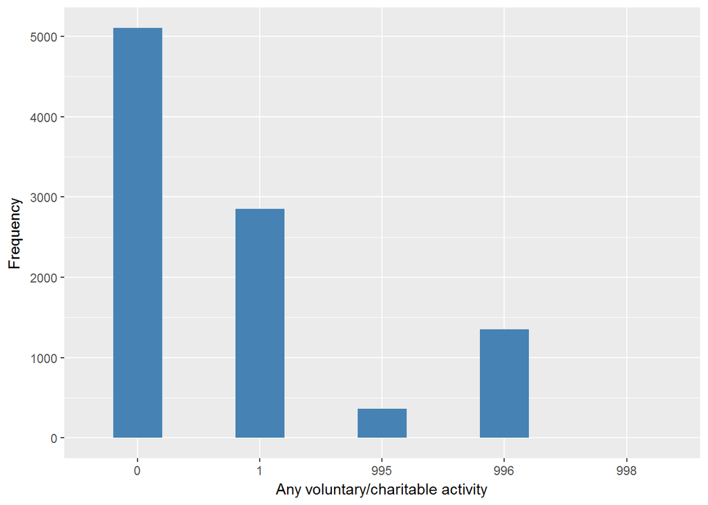

#### 2.1.7.4 Validation

# 3 Quality estimation